# Airline Baggage Complaints

Author

Joe Wald

The process of travelling by plane is arduous at best, and much more of a pain when problems do arise. Whether getting held up in security or having flight delays, airports are by far one of the most stressful places one can go.

Of all the possible issues within the sea of moving parts of an airport, having your baggage get lost, stolen, misplaced, or not reach your destination with you has to be one of the worst experiences for travellers to incur…

But these baggage issues may be much more predictable than many people previously may have thought.

The US Department of Transportation collects data of baggage complaints by passengers for all airlines in the US, and as shown is the plot of the number of these baggage complaint occurrances per flight scheduled by these airlines.

To take a closer look, we can split up this data into its multiple components to see a predictable seasonal pattern for these baggage issues.

The first row of the graph is the previous, unadjusted ratio of baggage complaints per scheduled flight

The second row consists of the same ratio but with the seasonal adjustment removed. With this row, we see the same pattern as is evident above, but with much less variation since the seasonal pattern has been removed.

Finally, the bottom graph gives us a clear picture of this seasonal change, and emphasises the seasonal cycle that takes place each year, which consists of large spikes at seemingly regular intervals.

As the graph shows us, United airlines has a much larger scale seasonal influence on its baggage complaints than American Eagle or Hawaiian Airlines as well as massive spikes each year.

In the following graph, we can take a closer look at the repeated seasonal pattern of baggage complaints for United Airlines.

The transition of the points from blue to red displays the yearly pattern each month, starting blue in January and ending red in December. Because of these colors, we can easily notice the large spike of baggage complaints per flight each year in the winter months, with the largest spike consistently occurring in December each year, which likely is a result of the Airline having to deal with a much larger volume of luggage due to increased holiday travel.

In addition to baggage complaints per flight, we can use the data to identify any disparities between the previous issues/flight ratio and a ratio of baggage complaints per passenger

At a glance, the seasonal component for baggage issues per passenger for American Eagle is now more dramatic than that of United, a contrast to the ratio for baggage issues per plane

We can take a side by side look at the seasonal changes of American Eagle and United Airlines for both ratios, baggage issues per passenger and baggage issues per flight.

As mentioned previously, we see that the American Eagle has more seasonal variation in baggage issues for each passenger, but much less seasonal variation that United when measuring baggage issues per flight. This likely is a result of United Airlines having larger flights, and therefore more passengers that could have baggage issues on each plane, along with a higher volume of luggage for the baggage crew to manage for each plane, increasing the likelihood of mishaps.

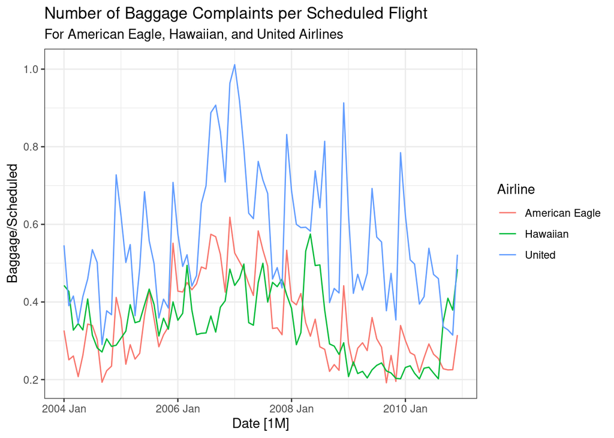

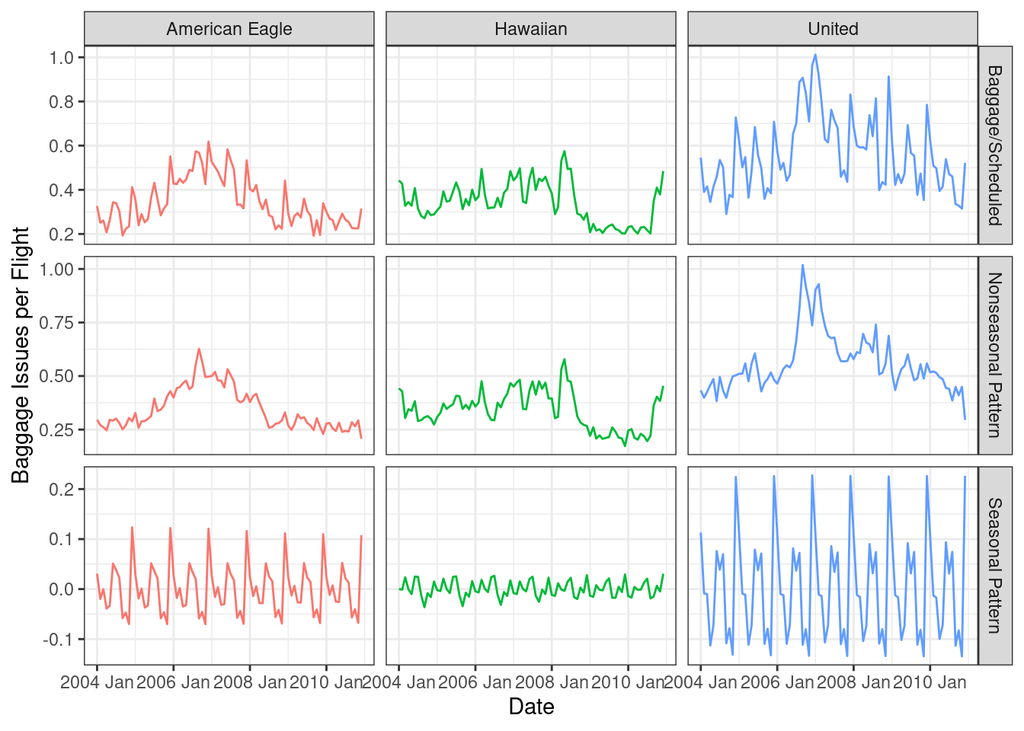

[figure not shown]

baggage_claim

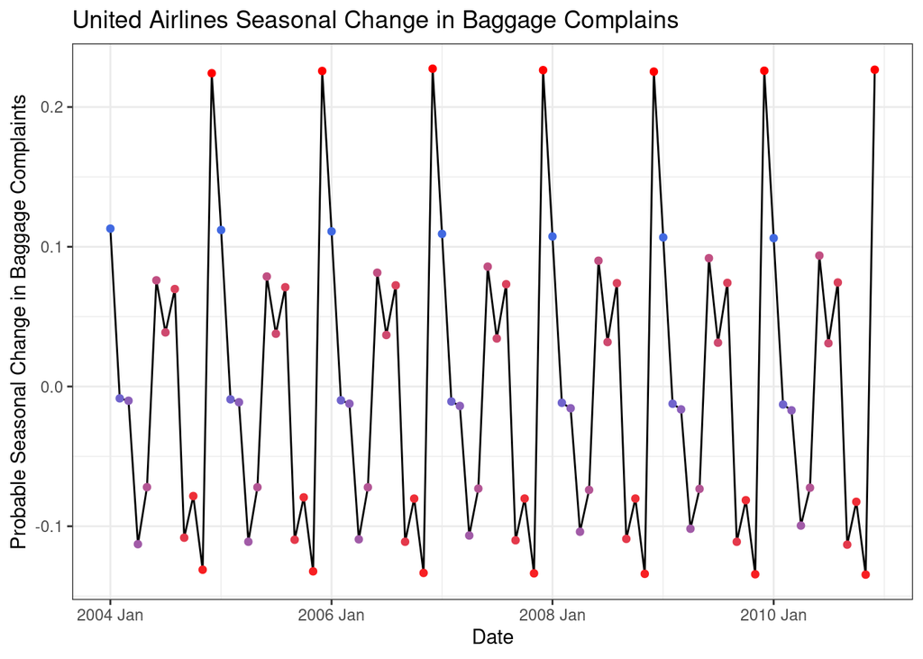

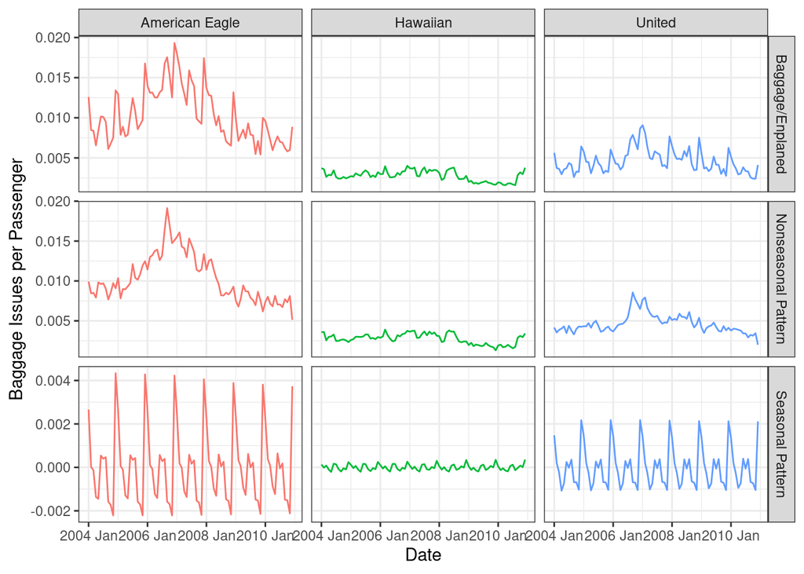

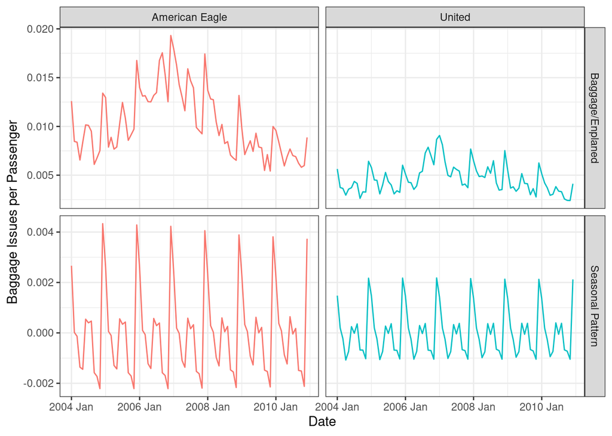

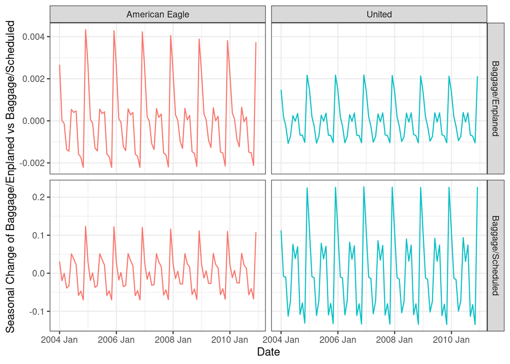

Year-round price information from: https://www.cnbc.com/select/best-time-to-book-flight-for-cheaper-tickets/ Baggage time series data from: https://www.kaggle.com/datasets/gabrielsantello/airline-baggage-complaints-time-series-dataset?resource=download